# Scenario Analysis for Temperature Binning Technical Documentation

Author: CH

Date: 2/18/2021

The GCAM reference scenario is from Fawcett et al., 2015. CO2 emissions reductions are linearly extrapolated between 2025 and 2100. Reductions begin the next time step after 2025 (i.e., 2026).

List of emissions included:  
ffi_emissions luc_emissions  
CH4_emissions N2O_emissions  
SO2_emissions CF4_emissions  
C2F6_emissions HFC125_emissions  
HFC134a_emissions HFC143a_emissions  
HFC227ea_emissions HFC245fa_emissions  
SF6_emissions NOX_emissions  
NMVOC_emissions CO_emissions  
BC_emissions OC_emissions

All other emissions in Hector where turned off. *Note, that this may bias the runs cooler without the additional CFCs and HFCs.

Run default Hector core with Reference Scenario

Reference Scenario output - [CO2] (ppmv), Forcing from CO2 (W m-2), Total Forcing (W m-2), Global Mean Temperature (dC)

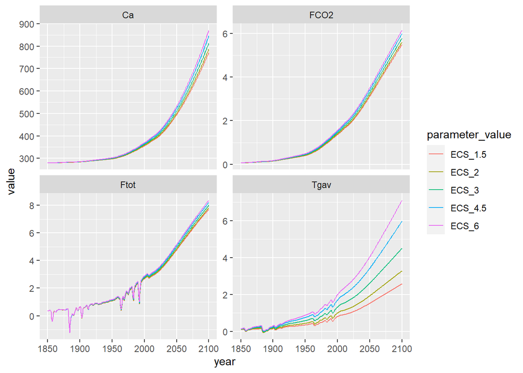

Run Hector with a decrease in FFI_emissions of 20%, 30%, 50%, 70%

Global Mean Temperature from 1850-2100 with all ECS and scenario combinations

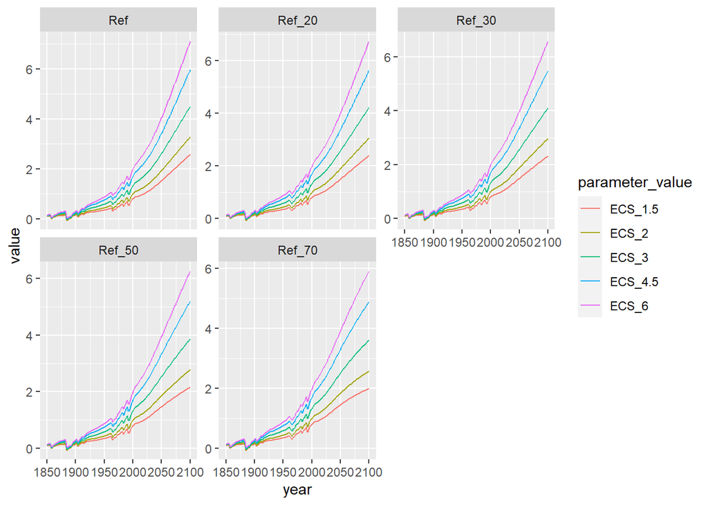

Table of scenario CO2 emissions

Scenario Emissions

| year | 2025.00 | 2100.00 |
| --- | --- | --- |
| ref | 12.13 | 25.79 |
| p20 | 12.13 | 20.63 |
| p30 | 12.13 | 18.05 |
| p50 | 12.13 | 12.89 |
| p70 | 12.13 | 7.73 |

I was initially surprised by how even with a 70% decrease, temperatures were still above 2 degrees. So I compared the CO2 emissions to the RCPs. not surprisingly, in order to get to 2 degrees emissions typically need to go negative. And even in our most aggressive case of 70% emissions in 2100 are still close to 8 GtC.

RCP Emissions

| year | 2025.00 | 2100.00 |
| --- | --- | --- |
| rcp26 | 8.22 | -0.93 |
| rcp45 | 10.41 | 4.20 |
| rcp60 | 9.40 | 13.13 |
| rcp85 | 12.60 | 28.60 |

NOTES: I had a hard time finding a GCAM reference with emissions needed to run Hector. I contacted PNNL to ask but what they sent over were the SSPs. They mentioned they could run a quick reference scenario from the latest release and send it over. If we are unhappy with this reference we can always ask them, but I’m not sure of their timeline.

To do -

1. before passing to IEc need to calculate temperature change from baseline. Need to double check the correct baseline.
2. Need to document the version of GCAM and Hector